# Visualization in `R`

Homework 3

Prof. Weldzius

Due Date: 2024-09-09

## Agenda

Visualization is one of `R`’s most impressive features, and arguably where it surpasses other competing programs like Python. Visualization can either be done in “base” `R`, or via a powerful set of functions included in the `ggplot` package. In this class, we will be working exclusively in `ggplot`, which is included in the `tidyverse` package.

Let’s start by loading our college data again.

## Load relevant libraries

```r
library(tidyverse)
```

## Load The Data

Once `tidyverse` is loaded, you can download the data directly from [GitHub](https://github.com/jbisbee1/DS1000_S2024/raw/main/data/sc_debt.Rds) using the `read_rds()` function. You should then open it in `R` by assigning it to an object with the `<-` command.

```r
df<-read_rds("https://github.com/rweldzius/PSC4175_F2024/raw/main/Data/sc_debt.Rds")
names(df)
```

```
##  [1] "unitid"         "instnm"         "stabbr"         "grad_debt_mdn"
##  [5] "control"        "region"         "preddeg"        "openadmp"
##  [9] "adm_rate"       "ccbasic"        "sat_avg"        "md_earn_wne_p6"
## [13] "ugds"           "costt4_a"       "selective"      "research_u"
```

## `ggplot`

`ggplot` works in layers, where the most simple layer is contained in the `ggplot()` function itself. Here, you set the x and y axes with a function called `aes()`. The primary inputs to `aes()` are `x` and `y`, although you can also set things like `color` and `fill` here.

Let’s create the first layer of our plot by using the `%>%` function to link our data with the `ggplot()` function.

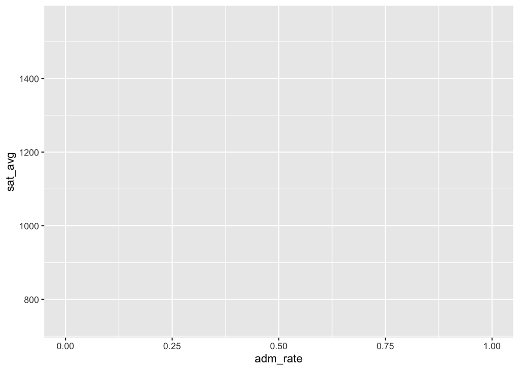

```r
df %>%
  ggplot(aes(x = adm_rate,y = sat_avg))
```

This gives us a rather ugly looking graph box, where we see the admissions rate on the x-axis (the horizontal axis) and the SAT scores on the y-axis (the vertical axis). However, there are no visuals like lines or bars or points to help us actually SEE the data. We know that ggplot has them on the axes we specified, but we haven’t drawn anything yet.

The next step is to add a “layer” to this plot that contains the visuals we want. To add a layer, we use the `+` sign to link our blank canvas to the function to draw the graph. In this situation, we are going to create a scatterplot using the function named `geom_point()`. (There are **many** other functions that are included with ggplot which will draw different plots…`geom_line()` and `geom_bar()` for example.)

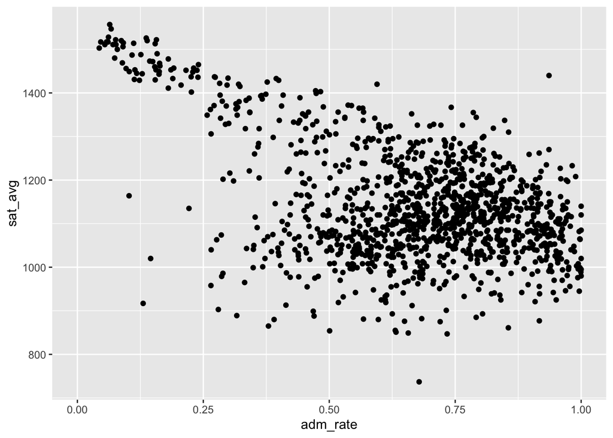

```r
df %>%
  ggplot(aes(x = adm_rate,y = sat_avg)) +
  geom_point()
```

# Tweaking Visuals

We have a visualization of our data! It suggests that there is a negative relationship between the admissions rate and SAT scores. When the admissions rate is very low (i.e., when schools are very selective), the average SAT scores of their students is above 1500 (top left part of the graph). When the admissions rate is very high, the average SAT scores is around 1000 (bottom right of the graph). Why might this be?

We can easily see this pattern just by looking at the data. However, we can make it even more clear by overlaying a “line of best fit” using a different function called `geom_smooth()`. This is going to be our **second** layer, meaning we need another `+` sign to link the function.

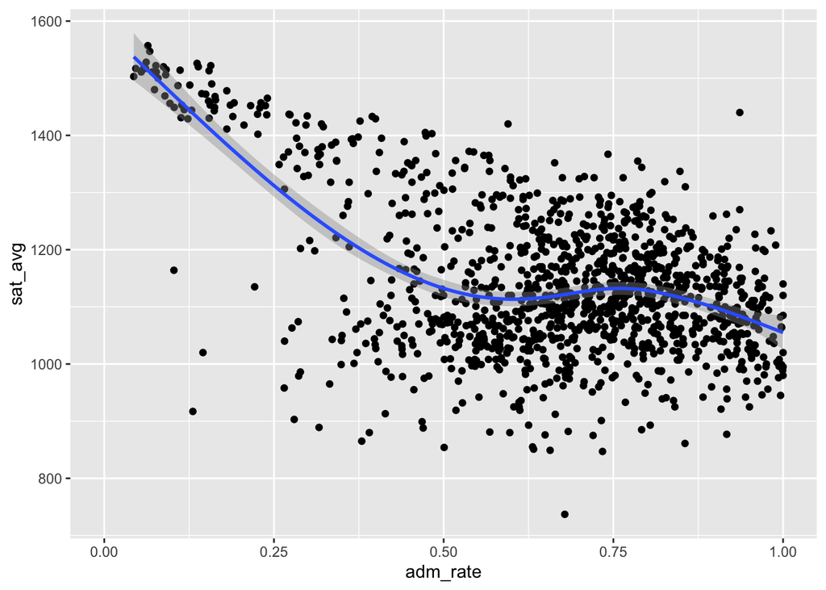

```r
df %>%
  ggplot(aes(x = adm_rate,y = sat_avg)) +
  geom_point() +
  geom_smooth()
```

The default behavior of `geom_smooth()` is to draw a slightly curvy line that bends. This is potentially useful, since it reveals that the negative relationship between the admissions rate and the SAT scores is stronger among more selective schools (i.e., those with an admissions rate less than 0.50 or 50%), but almost flat among less selective schools.

However, if all we want is the **overall** relationship drawn with a straight line, we need to tell `geom_smooth()` to draw a straight line with the input `method = "lm"`. (“lm” stands for “linear model”, a topic we will come back to later in the semester.)

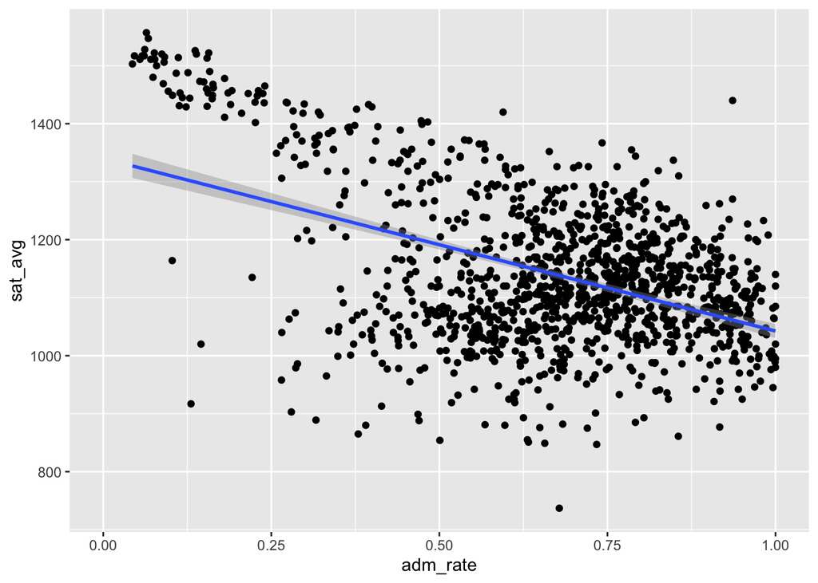

```r
df %>%
  ggplot(aes(x = adm_rate,y = sat_avg)) +
  geom_point() +
  geom_smooth(method = 'lm')
```

# Colors

We can continue to tweak this plot by changing the colors of the points. For example, we could color EVERY point red as follows

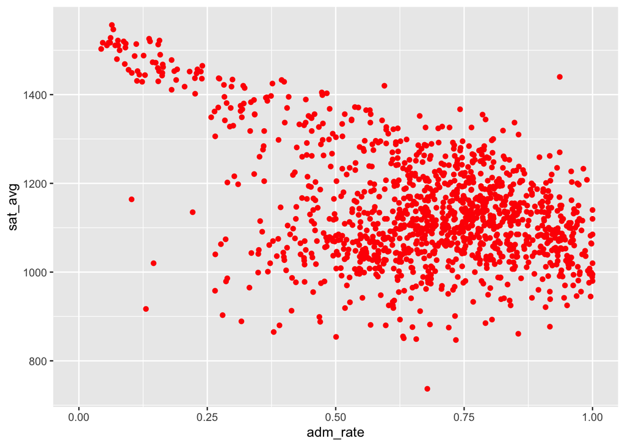

```r
df %>%
  ggplot(aes(x = adm_rate,y = sat_avg)) +
  geom_point(color = 'red')
```

However, we could instead color points *based on their value*. To do so, we want to move the `color` input **inside** the `aes()` function, and set it equal to the variable we want to visualize with color.

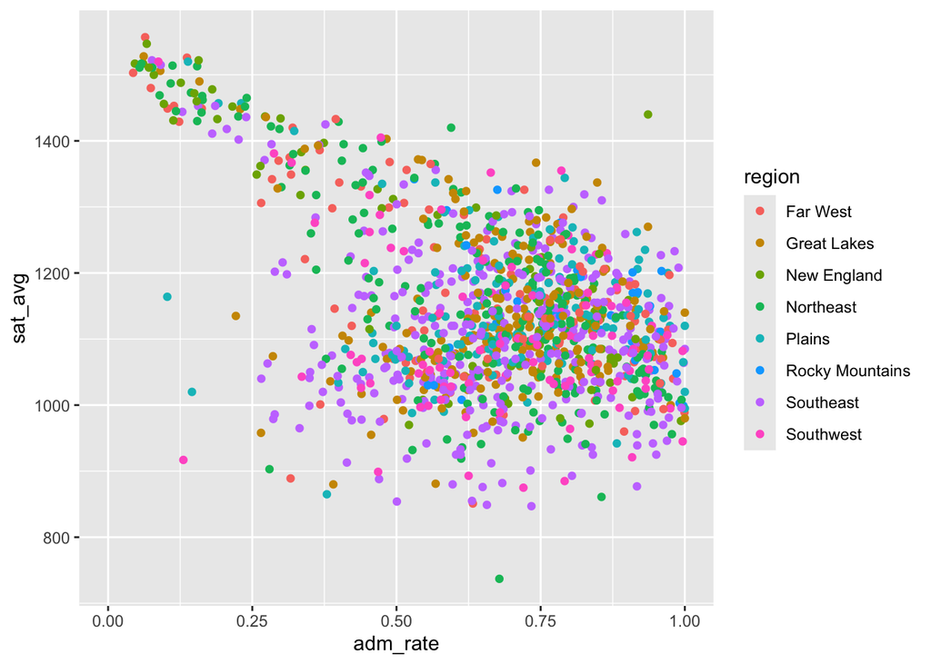

```r
df %>%
  ggplot(aes(x = adm_rate,y = sat_avg,
             color = region)) +
  geom_point()
```

We now have a legend added to the plot that tells us what each color refers to. In this example, we set the color equal to a categorical variable. We could instead set it equal to a continuous variable, which would give us a gradient.

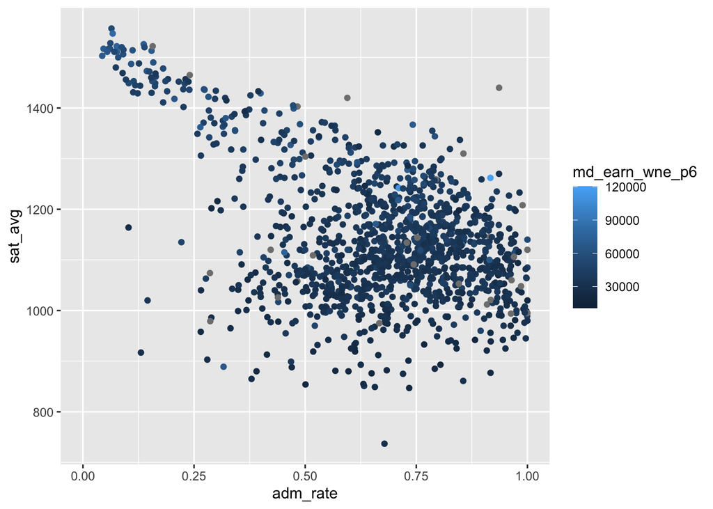

```r
df %>%
  ggplot(aes(x = adm_rate,y = sat_avg,
             color = md_earn_wne_p6)) +
  geom_point()
```

Here we see two patterns. First, we continue to see the negative relationship between the admissions rate and the SAT scores. Second, we can *kinda* see a relationship between future wages of graduates and their SAT scores.

If we don’t like the default choice of dark to light blue, we can modify this with `scale_color_gradient()`. As always, add another `+` to add the layer to the plot!

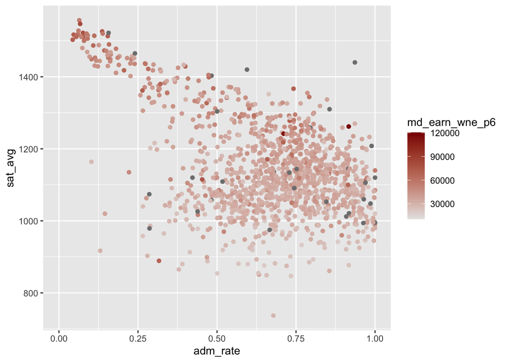

```r
df %>%
  ggplot(aes(x = adm_rate,y = sat_avg,
             color = md_earn_wne_p6)) +
  geom_point() +
  scale_color_gradient(low = 'grey90',high = 'darkred')
```

Note that some of the points are dark gray. These are schools that don’t report the median earnings of their recent graduates. These missing data default to a dark gray color.

*Quick Exercise* Re-do this plot but put `md_earn_wne_p6` on the y-axis, and `sat_avg` on the x-axis. Is there a relationship between SAT scores and earnings? Why might this be the case?

```r
# INSERT CODE HERE
```

## Other Aesthetics

We can also change the size of the points with the `size` input. As with `color`, this can either be set uniformly for all points, or we can make the size a function of another variable.

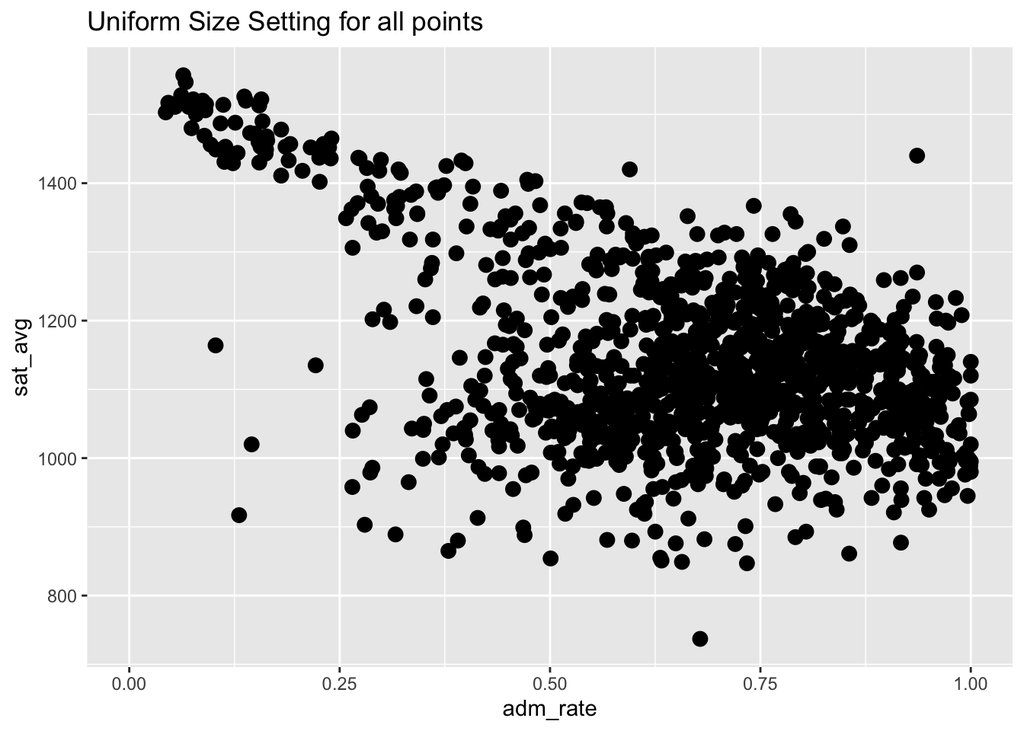

```r
df %>%
  ggplot(aes(x = adm_rate,y = sat_avg)) +
  geom_point(size = 3) +
  labs(title = 'Uniform Size Setting for all points')
```

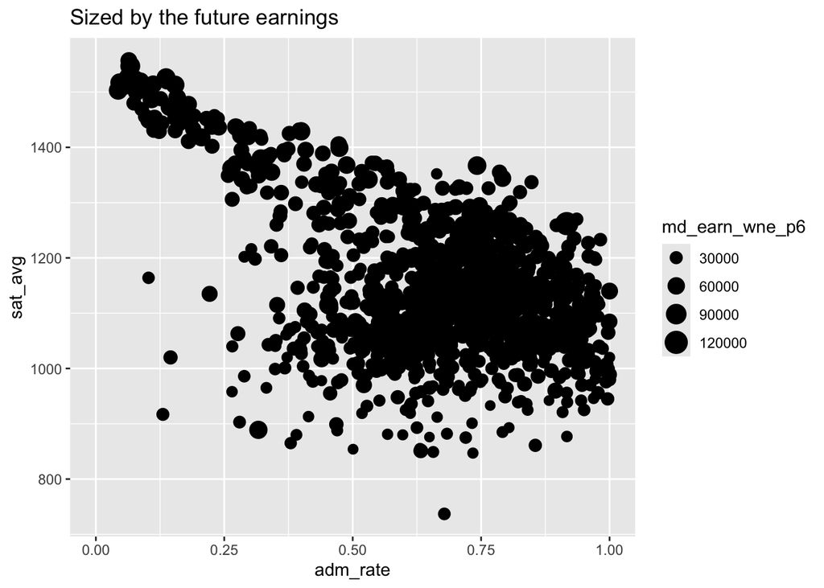

```r
df %>%
  ggplot(aes(x = adm_rate,y = sat_avg,
             size = md_earn_wne_p6)) +
  geom_point() +
  labs(title = 'Sized by the future earnings')
```

# Transparency

With so many points overlapping, especially with larger points, it becomes harder for the reader to see details. We can therefore adjust the transparency of these points with the `alpha` parameter, which can be a value between 0 and 1. Values closer to zero make the points more transparent, while values closer to 1 make them more opaque.

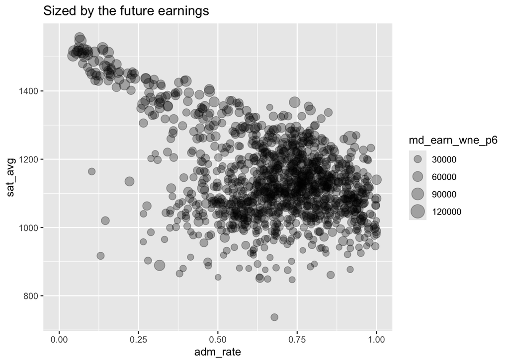

```r
df %>%
  ggplot(aes(x = adm_rate,y = sat_avg,
             size = md_earn_wne_p6)) +
  geom_point(alpha = .3) +
  labs(title = 'Sized by the future earnings')
```

# Other Types of Plots

This topic is very **deep** and you can spend years becoming an `R` expert and still find new ways of visualizing things. I encourage you to keep this link bookmarked: http://r-statistics.co/Complete-Ggplot2-Tutorial-Part1-With-R-Code.html

For now though, a few other types of plots:

## Histograms & Densities

For visualization of a single measure, a histogram is often useful. Here, we only need to set the x-axis variable. The `geom_histogram()` function will calculate the y-axis values for us, which is the number of schools falling into each bin. If we add all the bins together, we get the total number of schools in the data.

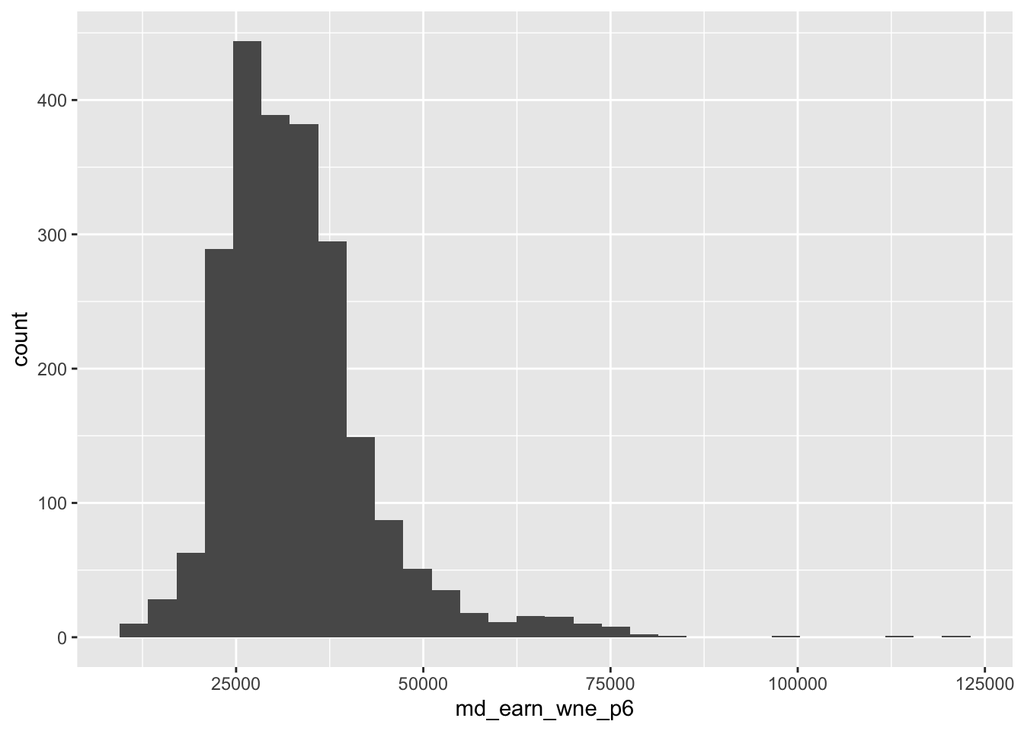

```r
df %>%
  ggplot(aes(md_earn_wne_p6)) +
  geom_histogram()
```

We can also get the same result with a density plot, which replaces the histogram with a line. The y-axis becomes the fraction of schools at each point on the x-axis, and adds up to 1.

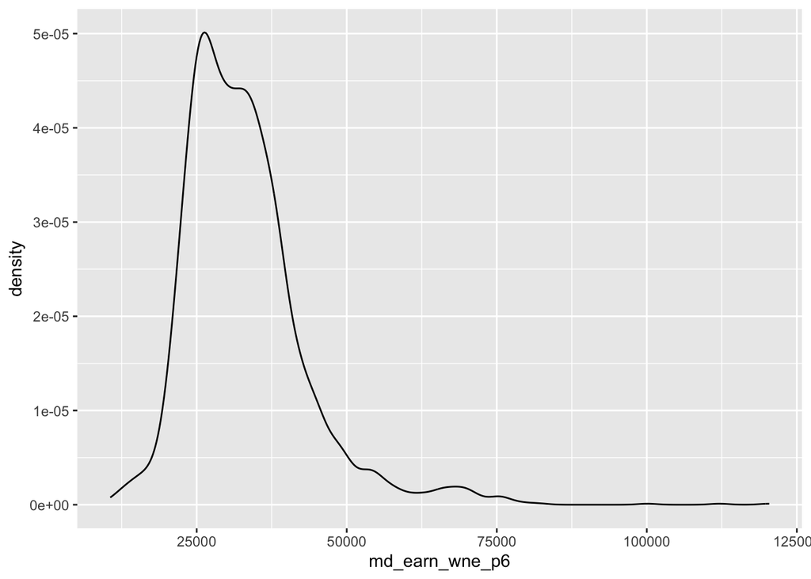

```r
df %>%
  ggplot(aes(x = md_earn_wne_p6)) +
  geom_density()
```

# Barplots

Barplots are another common type of data visualization. These are more appropriate for categorical data, or for types of continuous data where there are only a handful of distinct values.

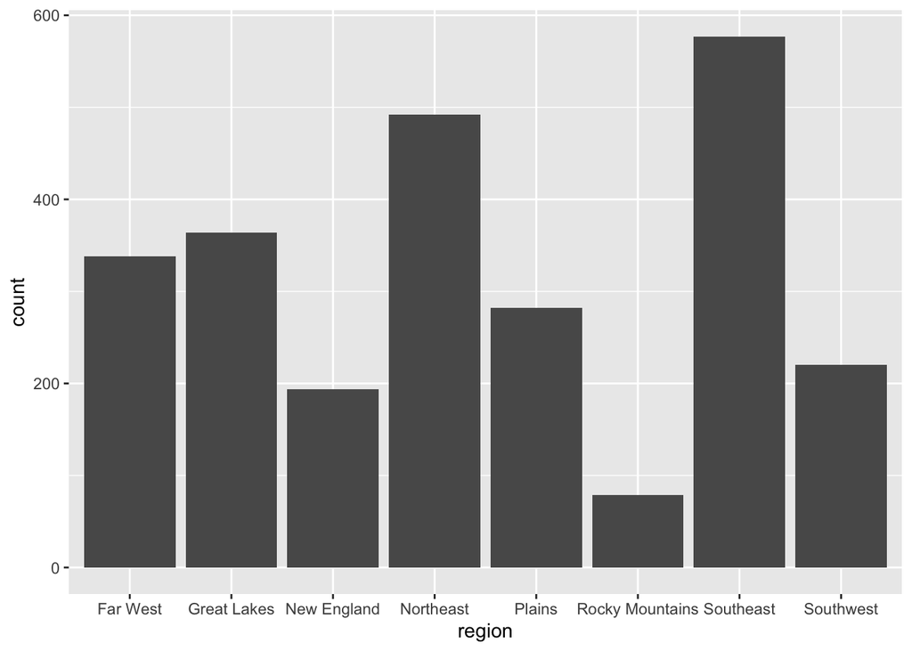

```r
df %>%
  ggplot(aes(x = region)) +
  geom_bar()
```